# Decision Tree Workbook

Machine Learning

30 August 2021

# Introduction

In this lab we are going to look at mental health in tech companies. The dataset we are going to use is from 2014 survey of attitudes towards mental health in tech companies. The objective for this analysis will be to identify the factors that lead towards an individual seeking help for a mental health condition.

# Set Up

### Load Packages

First lets load the packages we are going to use for this analysis.

```r
#install.packages("ggplot2")
#install.packages("rpart")                      # Popular decision tree algorithm
#install.packages("rattle")                 # Fancy tree plot
#install.packages("rpart.plot")             # Enhanced tree plots
#install.packages("RColorBrewer")               # Color selection for fancy tree plot
#install.packages("party")                  # Alternative decision tree algorithm
#install.packages("partykit")               # Convert rpart object to BinaryTree
#install.packages("caret")
# install.packages("splitstackshape")
library(ggplot2)
library(rpart)                      # Popular decision tree algorithm
library(rattle)                 # Fancy tree plot
library(rpart.plot)             # Enhanced tree plots
library(RColorBrewer)               # Color selection for fancy tree plot
library(party)                  # Alternative decision tree algorithm
library(partykit)               # Convert rpart object to BinaryTree
library(caret)
library(reshape2) # Load reshape 2 for melting
library(DMwR) # Load data mining with R for SMOTE
library(splitstackshape) # Used for stratified sampling
```

### Load data

The data for this analysis is stored as `mh_dat.rda`. To load it in we run the `load()` command.

```r
load("mh_dat.rda") # Load data into workspace
```

### View Data

We will again run the usual commands for viewing the start, end, and dimension of the dataset.

```r
head(mh_dat) # View first five rows
```

```
##   Age self_employed family_history remote_work tech_company   benefits
## 1  37          <NA>             No          No          Yes        Yes
## 2  44          <NA>             No          No           No Don't know
## 3  32          <NA>             No          No          Yes         No
## 4  31          <NA>            Yes          No          Yes         No
## 5  31          <NA>             No         Yes          Yes        Yes
## 6  33          <NA>            Yes          No          Yes        Yes
##   care_options wellness_program  anonymity              leave
## 1     Not sure               No        Yes      Somewhat easy
## 2           No       Don't know Don't know         Don't know
## 3           No               No Don't know Somewhat difficult
## 4          Yes               No         No Somewhat difficult
## 5           No       Don't know Don't know         Don't know
## 6     Not sure               No Don't know         Don't know
##   mental_health_consequence phys_health_consequence    coworkers supervisor
```

[output cut: 20 more lines]

```r
tail(mh_dat) # View last five rows
```

```
##      Age self_employed family_history remote_work tech_company   benefits
## 1253  29            No            Yes         Yes          Yes        Yes
## 1254  36            No            Yes          No           No Don't know
## 1255  26            No             No          No          Yes         No
## 1256  32            No            Yes         Yes          Yes        Yes
## 1257  34            No            Yes          No          Yes        Yes
## 1259  25            No            Yes          No           No        Yes
##      care_options wellness_program  anonymity              leave
## 1253          Yes              Yes        Yes         Don't know
## 1254           No              Yes Don't know      Somewhat easy
## 1255           No               No Don't know      Somewhat easy
## 1256          Yes               No        Yes Somewhat difficult
## 1257          Yes               No Don't know Somewhat difficult
## 1259          Yes               No        Yes         Don't know
##      mental_health_consequence phys_health_consequence    coworkers
```

[output cut: 20 more lines]

```r
dim(mh_dat) # View dimensions of data
```

```
## [1] 999  20
```

From this we see that we have 20 variables are 999 observations. The variables we have for this analysis are:

- age - The age of the survey respondent
- self_employed - Response to “Are you self employed?”
- family_history - Response to “Do you have a family history of mental illness”
- remote_work - Response to “Do you work remotely (outside of an office) at least 50% of the time?””
- tech_company - Response to “Is your employer primarily a tech company/organization?”
- benefits - Response to “Does your employer provide mental health benefits?”
- care_options - Response to “Do you know the options for mental health care your employer provides?”
- wellness_program - Response to “Has your employer ever discussed mental health as part of an employee wellness program?”
- anonymity - Response to “Is your anonymity protected if you choose to take advantage of mental health or substance abuse treatment resources?”
- leave - Response to “How easy is it for you to take medical leave for a mental health condition?”
- mentalhealthconsequence - Response to “Do you think that discussing a mental health issue with your employer would have negative consequences?”
- physhealthconsequence - Response to “Do you think that discussing a physical health issue with your employer would have negative consequences?”
- coworkers - Response to “Would you be willing to discuss a mental health issue with your coworkers?”
- supervisor - Response to “Would you be willing to discuss a mental health issue with your direct supervisor(s)?”
- mentalhealthinterview - Response to “Would you bring up a mental health issue with a potential employer in an interview?”
- physhealthinterview - Response to “Would you bring up a physical health issue with a potential employer in an interview?”
- mentalvsphysical - Response to “Do you feel that your employer takes mental health as seriously as physical health?””
- obs_consequence - Response to “Have you heard of or observed negative consequences for coworkers with mental health conditions in your workplace?”
- no_employees_mid - Mid-interval value of response to “How many employees does your company or organization have?”

We can then run the `summary()` command on the data to get a summary of the variables we have:

```r
summary(mh_dat) # Summarise data
```

```
##       Age        self_employed family_history remote_work tech_company
##  Min.   : 8.00   No  :855      No :549        No :695     No :180
##  1st Qu.:27.00   Yes :126      Yes:450        Yes:304     Yes:819
##  Median :31.00   NA's: 18
##  Mean   :32.27
##  3rd Qu.:36.00
##  Max.   :72.00
##  NA's   :4
##        benefits     care_options   wellness_program      anonymity
##  Don't know:295   No      :373   Don't know:136     Don't know:639
##  No        :297   Not sure:231   No        :668     No        : 58
##  Yes       :407   Yes     :395   Yes       :195     Yes       :302
##
##
##
##
##                 leave     mental_health_consequence phys_health_consequence
##  Don't know        :425   Maybe:382                 Maybe:223
##  Somewhat difficult:112   No   :357                 No   :718
##  Somewhat easy     :214   Yes  :260                 Yes  : 58
##  Very difficult    : 91
##  Very easy         :157
##
##
##         coworkers          supervisor  mental_health_interview
##  No          :206   No          :321   Maybe:151
##  Some of them:612   Some of them:290   No   :813
##  Yes         :181   Yes         :388   Yes  : 35
##
##
##
##
##  phys_health_interview  mental_vs_physical obs_consequence no_employess_mid
##  Maybe:447             Don't know:438      No :831         Min.   :   3.0
##  No   :396             No        :290      Yes:168         1st Qu.:  15.0
##  Yes  :156             Yes       :271                      Median :  63.0
##                                                            Mean   : 369.9
##                                                            3rd Qu.: 750.0
##                                                            Max.   :1250.0
##
##         resp_var
##  no_help    :362
##  sought_help:637
##
##
##
##
##
```

The `resp_var` variable contains the response we will use for this analysis. We have 362 individuals who have not sought help and 637 who have previously sough help.

Let’s create some visualizations to see if we can identify any relationships between our response variable and our explanatory variables.

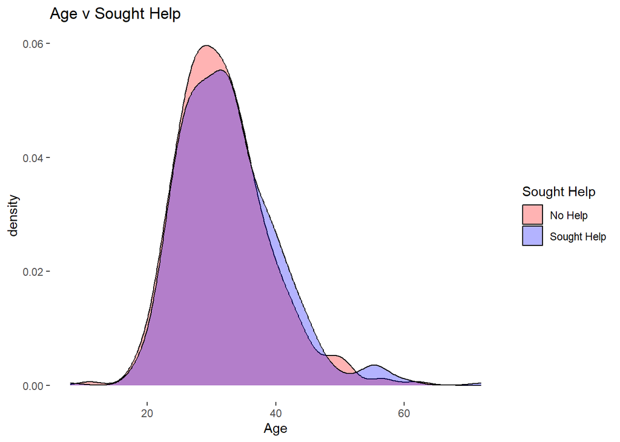

```r
g_1 <- ggplot(mh_dat, aes(x = Age, fill = resp_var)) + # Set x and y aesthetics
    geom_density(alpha = 0.3) + # Set geom density for density plot
    theme_bw() + # Set theme bw
    theme(panel.grid.major = element_blank(), # Turn of the background grid
    panel.grid.minor = element_blank(),
    panel.border = element_blank(),
    panel.background = element_blank()) +
    labs(x = "Age",  # Set plot labels
    fill = "Sought Help",
    title = "Age v Sought Help") +
    scale_fill_manual(values = c("no_help" = "red", "sought_help" = "blue"), # Manually set fill values
    labels = c("no_help" = "No Help", "sought_help" = "Sought Help"))
# Generate plot
g_1
```

There does not appear to be a strong relationship between age and seeking help. As many of our variables for this analysis are categorical, which can be challenging to visualize, what we will do is calculate the proportion of individuals who did not seek help for the response and then plot a heat map

```r
# Select variables to use
vars <- c("self_employed", "family_history", "remote_work", "tech_company", "benefits", "care_options",
"wellness_program", "anonymity", "obs_consequence")
# Create vector of responses
resps <- c("Yes", "No", "Don't know")
# Create empty data frame to store proportion
res_mat <- as.data.frame(matrix(NA, nrow = length(vars), ncol = length(resps)))
# Loop through and calculate proportion for each question and response
for(i in 1:nrow(res_mat)){
    # Proportion of no help for yes
    res_mat[i,1] <- (sum(mh_dat$resp_var == "no_help" &
    mh_dat[,vars[i]] == "Yes", na.rm = TRUE)/sum(!is.na(mh_dat[mh_dat[,vars[i]] == "Yes",vars[i]])))
    # Proportion of no help for no
    res_mat[i,2] <- (sum(mh_dat$resp_var == "no_help" &
    mh_dat[,vars[i]] == "No", na.rm = TRUE)/sum(!is.na(mh_dat[mh_dat[,vars[i]] == "No",vars[i]])))
    # Proportion of no help for don't know/not sure
    res_mat[i,3] <- (sum(mh_dat$resp_var == "no_help" &
    mh_dat[,vars[i]] %in% c("Don't know", "Not sure"), na.rm = TRUE)/
    sum(!is.na(mh_dat[mh_dat[,vars[i]] %in% c("Don't know", "Not sure"),vars[i]])))

}

# Add column names
names(res_mat) <- resps
# Join with variable vector
plot_dat <- cbind.data.frame(vars, res_mat)
# Melt data (Convert to long form)
m_dat <- melt(plot_dat, id.vars = "vars")
# View melted data
m_dat
```

```
##                vars   variable     value
## 1     self_employed        Yes 0.3809524
## 2    family_history        Yes 0.1888889
## 3       remote_work        Yes 0.3486842
## 4      tech_company        Yes 0.3724054
## 5          benefits        Yes 0.2506143
## 6      care_options        Yes 0.2227848
## 7  wellness_program        Yes 0.3025641
## 8         anonymity        Yes 0.2450331
## 9   obs_consequence        Yes 0.2380952
## 10    self_employed         No 0.3567251
## 11   family_history         No 0.5045537
## 12      remote_work         No 0.3683453
## 13     tech_company         No 0.3166667
## 14         benefits         No 0.3905724
## 15     care_options         No 0.4450402
## 16 wellness_program         No 0.3712575
## 17        anonymity         No 0.3448276
## 18  obs_consequence         No 0.3874850
## 19    self_employed Don't know       NaN
## 20   family_history Don't know       NaN
## 21      remote_work Don't know       NaN
## 22     tech_company Don't know       NaN
## 23         benefits Don't know 0.4881356
## 24     care_options Don't know 0.4675325
## 25 wellness_program Don't know 0.4044118
## 26        anonymity Don't know 0.4194053
## 27  obs_consequence Don't know       NaN
```

```r
# Calculate overall proportion of no help answers
prop_no <- sum(mh_dat$resp_var == "no_help")/sum(!is.na(mh_dat$care_options))
#print proportion of no help in data
prop_no
```

```
## [1] 0.3623624
```

We can then use the melted data to create a heat map. For this we can use `geom_tile()`. We will also scale the color to the proportion of respondents who did not seek help for each question. The proportion of the samples in the data who did not seek help is `0.3623624`. We can use `scale_fill_gradient2()` to control the colors of our heat map. For this we will set the midpoint at `0.3623624` and have values higher than that colored red and values below colored blue. Thus items with red squares are where their is a higher than expected proportion of individuals did not seek help.

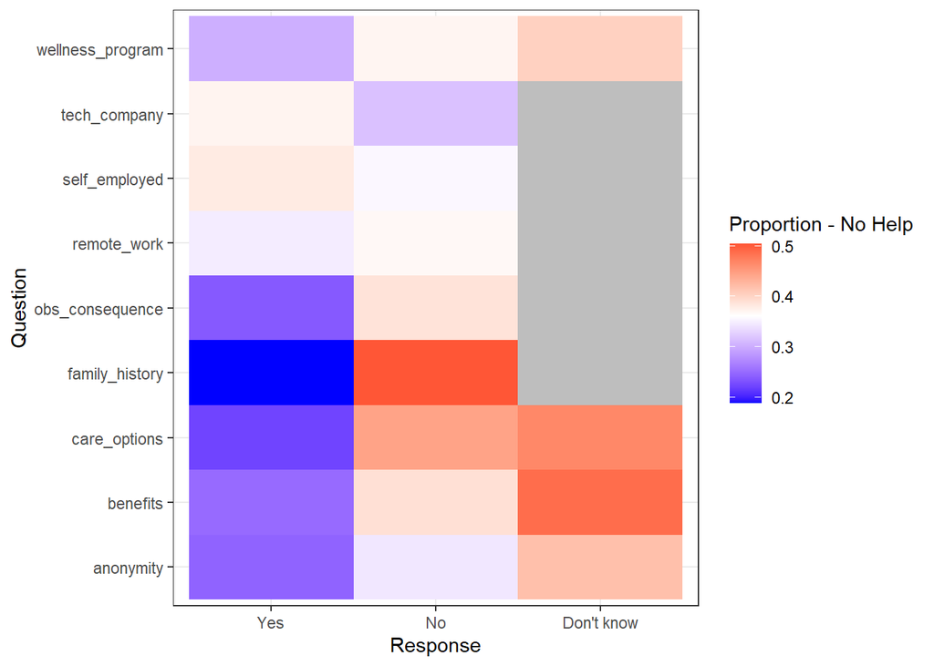

```r
g_2 <- ggplot(m_dat, aes(y = vars, x = variable, fill = value)) + # set aesthetics
    geom_tile() + # Use geom_tile for heatmap
    theme_bw() + # Set theme
    scale_fill_gradient2(low = "blue", # Choose low color
    mid = "white", # Choose mid color
    high = "red", # Choose high color
    midpoint = prop_no, # Choose mid point
    space = "Lab",
    na.value ="grey", # Choose NA value
    guide = "colourbar", # Set color bar
    aesthetics = "fill") + # Select aesthetics to apply
    labs(x = "Response", y = "Question", fill = "Proportion - No Help") # Set labels
g_2 # Generate plot
```

From the heat map it would appear that those who do not have a family history of mental health challenges are less likely to seek help, in addition those who do not have care options or are unaware of the care options or benefits are less likely to seek help.

# Decision Trees

We are now ready to fit a classification tree in order to predict if an individual will seek or not seek help for a mental health issue. To build a decision we will use the `rpart()` function. We will build our first tree using all the variables, using `~.` as we did for logistic and linear regression.

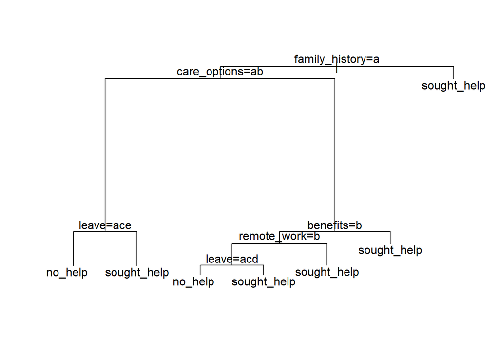

```r
tree_1 <- rpart(resp_var ~., # Set tree formula
data = mh_dat) # Set dataset
par(xpd = NA) # Set this avoid cut-off text
plot(tree_1)  # Plot tree
text(tree_1, digits = 3) # Add text
```

The default plot for decision trees in R is terrible. To remedy this we can use `fancyRpartPlot()`.

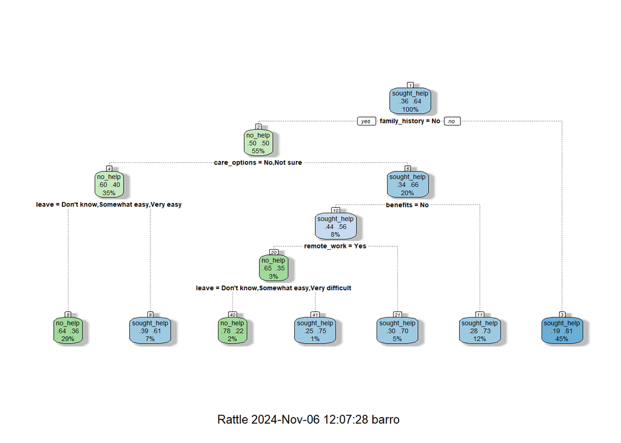

```r
fancyRpartPlot(tree_1) # Plot fancy tree
```

We can also the view the tree structure by calling the fitted tree:

```r
tree_1
```

```
## n= 999
##
## node), split, n, loss, yval, (yprob)
##       * denotes terminal node
##
##  1) root 999 362 sought_help (0.3623624 0.6376376)
##    2) family_history=No 549 272 no_help (0.5045537 0.4954463)
##      4) care_options=No,Not sure 352 142 no_help (0.5965909 0.4034091)
##        8) leave=Don't know,Somewhat easy,Very easy 286 102 no_help (0.6433566 0.3566434) *
##        9) leave=Somewhat difficult,Very difficult 66  26 sought_help (0.3939394 0.6060606) *
##      5) care_options=Yes 197  67 sought_help (0.3401015 0.6598985)
##       10) benefits=No 77  34 sought_help (0.4415584 0.5584416)
##         20) remote_work=Yes 31  11 no_help (0.6451613 0.3548387)
##           40) leave=Don't know,Somewhat easy,Very difficult 23   5 no_help (0.7826087 0.2173913) *
##           41) leave=Somewhat difficult,Very easy 8   2 sought_help (0.2500000 0.7500000) *
##         21) remote_work=No 46  14 sought_help (0.3043478 0.6956522) *
##       11) benefits=Don't know,Yes 120  33 sought_help (0.2750000 0.7250000) *
##    3) family_history=Yes 450  85 sought_help (0.1888889 0.8111111) *
```

If we run the `summary()` command on the tree this prints out a wealth of information regarding the tree.

```r
summary(tree_1)
```

```
## Call:
## rpart(formula = resp_var ~ ., data = mh_dat)
##   n= 999
##
##           CP nsplit rel error    xerror       xstd
## 1 0.09392265      0 1.0000000 1.0000000 0.04196939
## 2 0.03867403      2 0.8121547 0.8121547 0.03979027
## 3 0.01243094      3 0.7734807 0.7983425 0.03959012
## 4 0.01104972      5 0.7486188 0.8535912 0.04035640
## 5 0.01000000      6 0.7375691 0.8646409 0.04049887
##
## Variable importance
##          family_history            care_options                   leave
##                      46                      15                      10
##                benefits               anonymity             remote_work
##                       9                       4                       4
##        wellness_program                     Age         obs_consequence
##                       4                       2                       2
##        no_employess_mid      mental_vs_physical           self_employed
##                       1                       1                       1
## phys_health_consequence
##                       1
##
## Node number 1: 999 observations,    complexity param=0.09392265
##   predicted class=sought_help  expected loss=0.3623624  P(node) =1
##     class counts:   362   637
##    probabilities: 0.362 0.638
##   left son=2 (549 obs) right son=3 (450 obs)
##   Primary splits:
##       family_history  splits as  LR,  improve=49.283530, (0 missing)
##       care_options    splits as  LLR, improve=25.455800, (0 missing)
##       benefits        splits as  LLR, improve=17.153340, (0 missing)
##       anonymity       splits as  LLR, improve=11.917420, (0 missing)
##       obs_consequence splits as  LR,  improve= 6.237582, (0 missing)
##   Surrogate splits:
##       benefits                splits as  LLR, agree=0.577, adj=0.060, (0 split)
##       obs_consequence         splits as  LR,  agree=0.566, adj=0.036, (0 split)
##       mental_vs_physical      splits as  LRL, agree=0.560, adj=0.022, (0 split)
##       tech_company            splits as  RL,  agree=0.554, adj=0.009, (0 split)
##       phys_health_consequence splits as  LLR, agree=0.554, adj=0.009, (0 split)
```

[output cut: 101 more lines]

```
##
## Node number 21: 46 observations
##   predicted class=sought_help  expected loss=0.3043478  P(node) =0.04604605
##     class counts:    14    32
##    probabilities: 0.304 0.696
##
## Node number 40: 23 observations
##   predicted class=no_help      expected loss=0.2173913  P(node) =0.02302302
##     class counts:    18     5
##    probabilities: 0.783 0.217
##
## Node number 41: 8 observations
##   predicted class=sought_help  expected loss=0.25  P(node) =0.008008008
##     class counts:     2     6
##    probabilities: 0.250 0.750
```

The initial table has some valuable information:

- CP - Complexity parameter divided by the misclassification rate from the root node. The default stopping value for cp is 0.01
- nsplit - Number of terminal nodes at each level of the complexity parameter.
- rel_error - Relative error or misclassification for the tree at that point. To get absolute error multiply by the error in the root node.
- xerror/xstd - Refer to results of a cross-validation procedure. Ideally we want to select the tree with the lowest xerror +/- 1 standard deviation.

The second table down provides the variable importance calculated for each of the variables in the tree.

Most of the rest of the output is rather challenging to interpret however you will notice that for some nodes we see the term surrogate splits mentioned. This refers to how trees deal with missing data. When a sample has a missing value for a splitter, what decision trees do is look for a variable which splits the samples in a similar fashion to the splitting variable and uses that to split samples for which the original splitting variable is missing.

### Selecting CP

In fitting a basic tree we are most interested in the complexity parameter. To view the complexity parameter table from the summary statistics by itself we can run `printcp()`:

```r
printcp(tree_1) # Print complexity parameter table
```

```
##
## Classification tree:
## rpart(formula = resp_var ~ ., data = mh_dat)
##
## Variables actually used in tree construction:
## [1] benefits       care_options   family_history leave          remote_work
##
## Root node error: 362/999 = 0.36236
##
## n= 999
##
##         CP nsplit rel error  xerror     xstd
## 1 0.093923      0   1.00000 1.00000 0.041969
## 2 0.038674      2   0.81215 0.81215 0.039790
## 3 0.012431      3   0.77348 0.79834 0.039590
## 4 0.011050      5   0.74862 0.85359 0.040356
## 5 0.010000      6   0.73757 0.86464 0.040499
```

A better way to interpret the complexity parameter is to plots its progression and compare different values with the relative error they lead to:

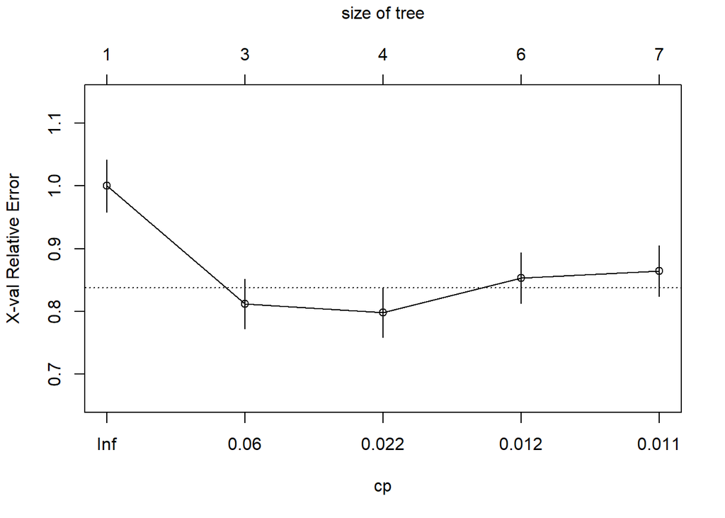

```r
plotcp(tree_1) # Plot cp
```

Ultimately the complexity parameter is used to control the size of the tree. Smaller values will build larger trees (with cp =0 building a maximal tree) and larger values dictating that a larger reduction in error must be achieved before growing the tree. We want to find a model which minimizes the cross-validation relative error. To do this we must adjust some parameters in our rpart model. From the graph we can see that the lowest relative error occurs when cp = 0.022. To set this parameter in our model we can use `control = rpart.control()` inside the rpart function:

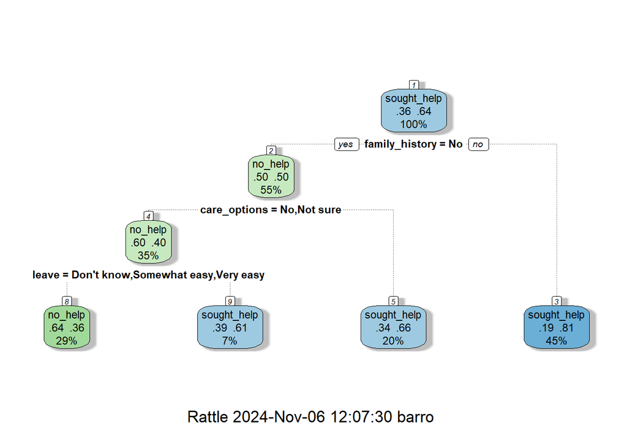

```r
tree_2 <- rpart(resp_var ~., # Set tree formula
data = mh_dat, # Set data
control = rpart.control(cp = 0.022)) # Set parameters
fancyRpartPlot(tree_2) # Plot fancy tree
```

We can also set some other parameters inside `rpart.control()`:

- minsplit - the minimum number of observations that must exist in a node in order for a split to be attempted.
- minbucket - the minimum number of observations in any terminal node.
- xval - number of cross-validations.
- maxdepth - Set the maximum depth of any node of the final tree, with the root node counted as depth 0. Values greater than 30 rpart will give nonsense results on 32-bit machines.

## Imbalanced Data

For this dataset we have a slightly imbalanced dataset. There are 637 samples who sought help and 362 individuals who did not seek help. This may have an effect on our classifier paying more attention to the majority class. To remedy this we can use:

- Bootstrap re-sampling - Sample with replacement from the minority class to re-balance the data
- SMOTE - Synthetic minority over-sampling technique, this creates new synthetic samples for the minority class.

### Bootstrap resampling

To carry out bootstrap re-sampling we simply generate a random selection of indices from the minority class to use in the model, in effect this randomly duplicates some of the minority class samples:

```r
# Split data into help and no help classes
no_help <- mh_dat[which(mh_dat$resp_var == "no_help"),] # Select minority samples
help <- mh_dat[which(mh_dat$resp_var == "sought_help"),] # Select majority samples
nrow(no_help) # Rows in no help
```

```
## [1] 362
```

```r
nrow(help) # Rows in help
```

```
## [1] 637
```

```r
set.seed(123456) # Set seed for sampling
no_help_boot <- no_help[sample(1:nrow(no_help), size = nrow(help), replace =TRUE),] # Create bootstrap sample
nrow(no_help_boot) # Check rows of bootstrap sample
```

```
## [1] 637
```

```r
use_dat <- rbind.data.frame(help, no_help_boot) # Join data together
```

We can now fit a tree on the bootstrapped data:

[figure not shown]

```r
tree_3 <- rpart(resp_var ~., # Set tree formula
data = use_dat) # Set data
fancyRpartPlot(tree_3) # Plot fancy tree
```

As can be seen in the graph the root node now contains an even number of both the minority and majority classes.

### SMOTE

SMOTE creates new synthetic observations using the observations already present in this class using the nearest neighbors of the samples. It is also possible to under-sample with SMOTE.

[figure not shown]

Multi-Class Data

[figure not shown]

Link data

[figure not shown]

Creat new samples

We can run SMOTE using `SMOTE()`. The amount of samples to generate for the minority class is set using `perc.over`. Here we will set this parameter to 100 to have equal class representation in the dataset.

```r
smote_dat <- SMOTE(resp_var ~ ., # Set prediction formula
mh_dat, # Set dataset
perc.over = 100) # Select oversampling for minority class
summary(smote_dat$resp_var)
```

```
##     no_help sought_help
##         724         724
```

We can now build a tree on the SMOTE dataset:

[figure not shown]

```r
tree_4 <- rpart(resp_var ~., # Set tree formula
data = smote_dat) # Set data
fancyRpartPlot(tree_4) # Plot fancy tree
```

## Prediction prelim

To test how our model will perform on new data we can split the data into training and test sets. We will use the data which is already split into help and no help to ensure we have an equal proportion of samples in each class for both our training and test sets. We will use 20% of the data for testing. To do this we can use the stratified function which will create a stratified sample for our dataset.

```r
 set.seed(123456) # Set seed
# Perform stratified sampling
 split_dat <- stratified(mh_dat, # Set dataset
                         group = "resp_var", # Set variables to use for stratification
                         size = 0.2,  # Set size of test set
                         bothSets = TRUE ) # Return both training and test sets
 # Extract train data
 train_dat <- split_dat[[2]]
 # Extract test data
 test_dat <- split_dat[[1]]

# Check size
nrow(train_dat)
```

```
## [1] 800
```

```r
nrow(test_dat)
```

```
## [1] 199
```

So we have 800 training samples and 199 test samples. We can now build a tree on the training data:

[figure not shown]

```r
tree_5 <- rpart(resp_var ~., # Set tree formula
data = train_dat) # Set data
fancyRpartPlot(tree_5) # Plot fancy tree
```

We can then predict the class of the test samples:

```r
preds <- predict(tree_5, test_dat) # Predict test samples
```

Let’s look at the predicted vs actual values:

```r
head(cbind.data.frame(preds, test_dat$resp_var))
```

```
##     no_help sought_help test_dat$resp_var
## 1 0.1894150   0.8105850       sought_help
## 2 0.1894150   0.8105850       sought_help
## 3 0.8181818   0.1818182       sought_help
## 4 0.1894150   0.8105850       sought_help
## 5 0.1894150   0.8105850       sought_help
## 6 0.6071429   0.3928571       sought_help
```

We can the visualize the results of our prediction by class:

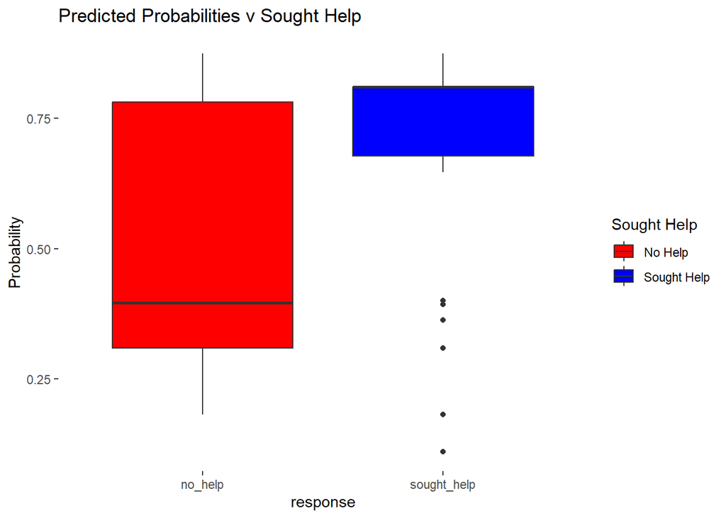

```r
# Join predictions (second column is prob of sought help) and test response
plot_dat <- cbind.data.frame(preds[,2], test_dat$resp_var)
names(plot_dat) <- c("probability", "response")
g_3 <- ggplot(plot_dat, aes(y = probability, x = response, fill = response)) +
geom_boxplot() +
theme_bw() +
theme(panel.grid.major = element_blank(), # Turn of the background grid
panel.grid.minor = element_blank(),
panel.border = element_blank(),
panel.background = element_blank()) +
labs(y = "Probability",  # Set plot labels
fill = "Sought Help",
title = "Predicted Probabilities v Sought Help") +
scale_fill_manual(values = c("no_help" = "red", "sought_help" = "blue"), # Manually set fill values
labels = c("no_help" = "No Help", "sought_help" = "Sought Help"))
g_3
```

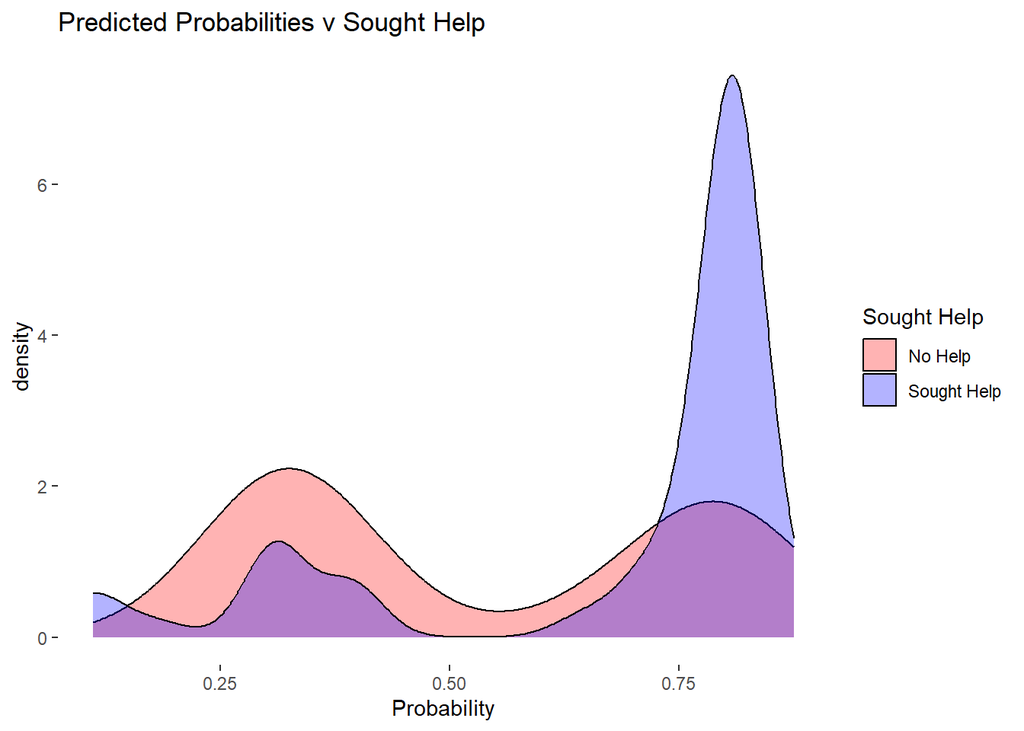

```r
g_4 <- ggplot(plot_dat, aes(x = probability, fill = response)) +
geom_density(alpha = 0.3) +
theme_bw() +
theme(panel.grid.major = element_blank(), # Turn of the background grid
panel.grid.minor = element_blank(),
panel.border = element_blank(),
panel.background = element_blank()) +
labs(x = "Probability",  # Set plot labels
fill = "Sought Help",
title = "Predicted Probabilities v Sought Help") +
scale_fill_manual(values = c("no_help" = "red", "sought_help" = "blue"), # Manually set fill values
labels = c("no_help" = "No Help", "sought_help" = "Sought Help"))
g_4
```

Lets use a cut-off of 0.6 and see what the results would look like in a confusion matrix:

```r
preds_char <- rep("no_help", nrow(plot_dat)) # Create vector for predictions with deafult value
preds_char[which(plot_dat$probability >= 0.6)] <- "sought_help" # Select sought help predictions
confusionMatrix(table(preds_char, plot_dat$response)) # Create confusion matrix
```

```
## Confusion Matrix and Statistics
##
##
## preds_char    no_help sought_help
##   no_help          39          29
##   sought_help      33          98
##
##                Accuracy : 0.6884
##                  95% CI : (0.6191, 0.7521)
##     No Information Rate : 0.6382
##     P-Value [Acc > NIR] : 0.07944
##
##                   Kappa : 0.3171
##
##  Mcnemar's Test P-Value : 0.70320
##
##             Sensitivity : 0.5417
##             Specificity : 0.7717
##          Pos Pred Value : 0.5735
##          Neg Pred Value : 0.7481
##              Prevalence : 0.3618
##          Detection Rate : 0.1960
##    Detection Prevalence : 0.3417
##       Balanced Accuracy : 0.6567
##
##        'Positive' Class : no_help
##
```

Lets see if using smote on the training data can help improve our accuracy;

```r
# Run smote
smote_dat_2 <- SMOTE(resp_var ~ ., # Set prediction formula
train_dat, # Set dataset
perc.over = 100) # Select oversampling for minority class
# Build tree
tree_6 <- rpart(resp_var ~., # Set tree formula
data = smote_dat_2) # Set data
# Predict test data
preds <- predict(tree_6, test_dat)
# Extract probabilities and produce table
plot_dat <- cbind.data.frame(preds[,2], test_dat$resp_var)
names(plot_dat) <- c("probability", "response")
preds_char <- rep("no_help", nrow(plot_dat)) # Create vector for predictions with deafult value
preds_char[which(plot_dat$probability >= 0.6)] <- "sought_help" # Select sought help predictions
confusionMatrix(table(preds_char, plot_dat$response)) # Create confusion matrix
```

```
## Confusion Matrix and Statistics
##
##
## preds_char    no_help sought_help
##   no_help          46          42
##   sought_help      26          85
##
##                Accuracy : 0.6583
##                  95% CI : (0.5879, 0.7239)
##     No Information Rate : 0.6382
##     P-Value [Acc > NIR] : 0.30462
##
##                   Kappa : 0.294
##
##  Mcnemar's Test P-Value : 0.06891
##
##             Sensitivity : 0.6389
##             Specificity : 0.6693
##          Pos Pred Value : 0.5227
##          Neg Pred Value : 0.7658
##              Prevalence : 0.3618
##          Detection Rate : 0.2312
##    Detection Prevalence : 0.4422
##       Balanced Accuracy : 0.6541
##
##        'Positive' Class : no_help
##
```

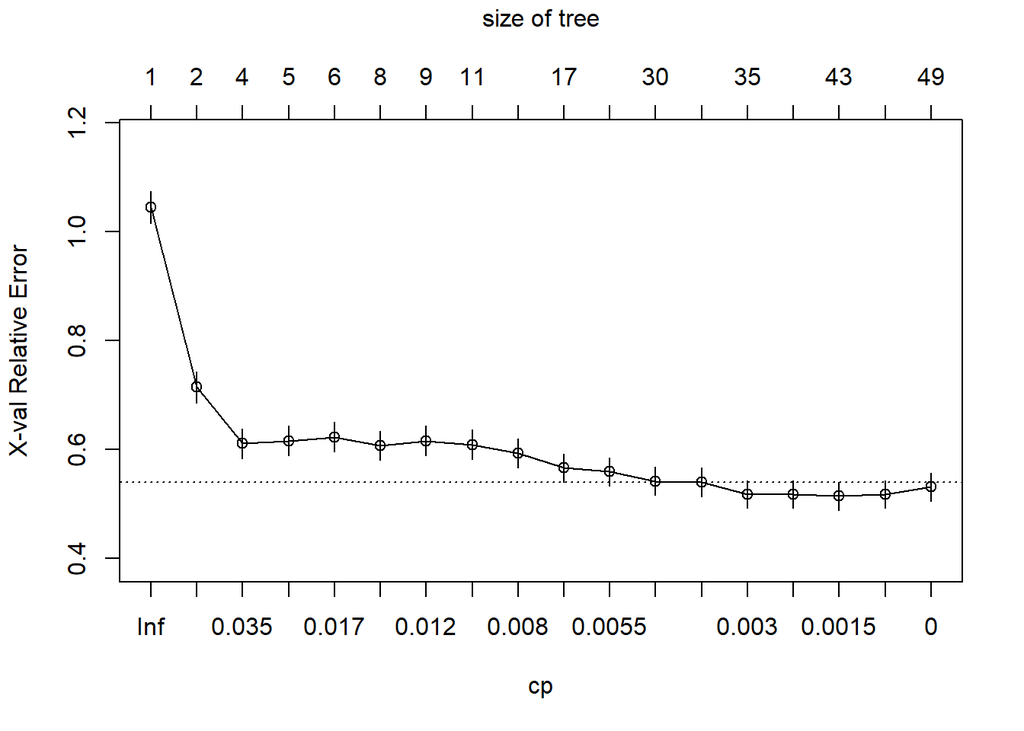

```r
# Set seed
set.seed(999999)
# Build tree
tree_7 <- rpart(resp_var ~., # Set tree formula
data = smote_dat_2, # Set data
control = rpart.control(cp = 0)) # Select cp
# Plot CP
plotcp(tree_7)
```

```r
# Print CP
printcp(tree_7)
```

```
##
## Classification tree:
## rpart(formula = resp_var ~ ., data = smote_dat_2, control = rpart.control(cp = 0))
##
## Variables actually used in tree construction:
##  [1] Age                       anonymity
##  [3] benefits                  care_options
##  [5] coworkers                 family_history
##  [7] leave                     mental_health_consequence
##  [9] mental_health_interview   mental_vs_physical
## [11] no_employess_mid          obs_consequence
## [13] phys_health_interview     supervisor
## [15] tech_company              wellness_program
##
## Root node error: 580/1160 = 0.5
```

[output cut: 22 more lines]

The cp appears to be minimized about 0.004. Instead of returning probabilities from the prediction we can set `type="class"` in the predict function to get the function to return a class prediction.

```r
# Build tree
tree_8 <- rpart(resp_var ~., # Set tree formula
data = smote_dat_2, # Set data
control = rpart.control(cp = 0.004)) # Select cp

# Predict test data
preds <- predict(tree_8, test_dat, type = "class")

confusionMatrix(table(preds,  test_dat$resp_var)) # Create confusion matrix
```

```
## Confusion Matrix and Statistics
##
##
## preds         no_help sought_help
##   no_help          41          46
##   sought_help      31          81
##
##                Accuracy : 0.6131
##                  95% CI : (0.5416, 0.6811)
##     No Information Rate : 0.6382
##     P-Value [Acc > NIR] : 0.7921
##
##                   Kappa : 0.1983
##
##  Mcnemar's Test P-Value : 0.1106
##
##             Sensitivity : 0.5694
##             Specificity : 0.6378
##          Pos Pred Value : 0.4713
##          Neg Pred Value : 0.7232
##              Prevalence : 0.3618
##          Detection Rate : 0.2060
##    Detection Prevalence : 0.4372
##       Balanced Accuracy : 0.6036
##
##        'Positive' Class : no_help
##
```

That led to a decrease in performance for the tree, we are now likely overfitting the data.

# Exercises

For this analysis we will be looking at heart failure data. The dataset is stored as:

```r
load(file="heart_failure_data.rda")
```

Diagnosing those at risk of death due to heart failure is critical in order to reduce the associated deaths. Those who are determined to be at risk of death due to heart failure can be treated with more extreme measures such as surgery whereas those who are not can utilize more preventative methods such as lifestyle changes. Heart failure mortality can be difficult to predict as there are often many different factors involved and the individuality of patients means certain conditions are likely to be more impact than others. Heart Failure is a slow and gradual process with certain stages, correlated with decreased heart functioning. Certain conditions such as high blood pressure and coronary artery disease are strongly correlated with heart failure.

Dataset from Davide Chicco, Giuseppe Jurman: Machine learning can predict survival of patients with heart failure from serum creatinine and ejection fraction alone. BMC Medical Informatics and Decision Making 20, 16 (2020)

Let’s view a summary of the data:

```r
summary(heart_data)
```

```
##       age           anaemia       creatinine_phosphokinase    diabetes
##  Min.   :40.00   Min.   :0.0000   Min.   :  23.0           Min.   :0.0000
##  1st Qu.:51.00   1st Qu.:0.0000   1st Qu.: 116.5           1st Qu.:0.0000
##  Median :60.00   Median :0.0000   Median : 250.0           Median :0.0000
##  Mean   :60.83   Mean   :0.4314   Mean   : 581.8           Mean   :0.4181
##  3rd Qu.:70.00   3rd Qu.:1.0000   3rd Qu.: 582.0           3rd Qu.:1.0000
##  Max.   :95.00   Max.   :1.0000   Max.   :7861.0           Max.   :1.0000
##  ejection_fraction high_blood_pressure   platelets      serum_creatinine
##  Min.   :14.00     Min.   :0.0000      Min.   : 25100   Min.   :0.500
##  1st Qu.:30.00     1st Qu.:0.0000      1st Qu.:212500   1st Qu.:0.900
##  Median :38.00     Median :0.0000      Median :262000   Median :1.100
##  Mean   :38.08     Mean   :0.3512      Mean   :263358   Mean   :1.394
##  3rd Qu.:45.00     3rd Qu.:1.0000      3rd Qu.:303500   3rd Qu.:1.400
##  Max.   :80.00     Max.   :1.0000      Max.   :850000   Max.   :9.400
##   serum_sodium        sex            smoking       DEATH_EVENT
##  Min.   :113.0   Min.   :0.0000   Min.   :0.0000   0:203
##  1st Qu.:134.0   1st Qu.:0.0000   1st Qu.:0.0000   1: 96
##  Median :137.0   Median :1.0000   Median :0.0000
##  Mean   :136.6   Mean   :0.6488   Mean   :0.3211
##  3rd Qu.:140.0   3rd Qu.:1.0000   3rd Qu.:1.0000
##  Max.   :148.0   Max.   :1.0000   Max.   :1.0000
```

The variables we have are:

- age - Patient Age
- anaemia - Decrease of red blood cells or hemoglobin (boolean)
- creatinine_phosphokinase - Level of the CPK enzyme in the blood (mcg/L)
- diabetes - If the patient has diabetes (boolean)
- ejection_fraction - Percentage of blood leaving the heart at each contraction (percentage)
- high_blood_pressure - If the patient has hypertension (boolean)
- platelets - Platelets in the blood (kiloplatelets/mL)
- serum_creatinine - Level of serum creatinine in the blood (mg/dL)
- serum_sodium - Level of serum sodium in the blood (mEq/L)
- sex - Woman or man (binary)
- smoking - If the patient smokes or not (boolean)
- DEATH_EVENT - If the patient deceased during the follow-up period (boolean)

Our objectives for this analysis are two-fold, we want to identify the factors which lead to heart failure and build a model which can predict heart failure.

Please attempt the following exercises:

- Create two visualizations which may reveal variables with potential predictive power.
- Select the optimal CP for a decision tree built on this dataset.
- Construct a tree using the full dataset with the optimal CP.
- Plot the constructed decision tree.
- What are the key variables which play a role in heart failure?

Next lets split the data into training and test sets:

```r
 set.seed(123456) # Set seed
# Perform stratified sampling
 split_dat <- stratified(heart_data, group = "DEATH_EVENT", size = 0.2, bothSets = TRUE )
 # Extract train data
 train_data <- split_dat[[2]]
 # Extract test data
 test_data <- split_dat[[1]]
```

- Construct a decision tree on the training data
- How has the tree changed from the tree built on the full dataset?
- Predict the outcome for the test data.
- Visualize the results of the predictions in a confusion matrix.
- What was the accuracy of the decision tree? What was the balanced accuracy?